# Wellington R Users Group

Community Questionnaire Results

August 08, 2017

# 44

total responses

### How long have you been using R?

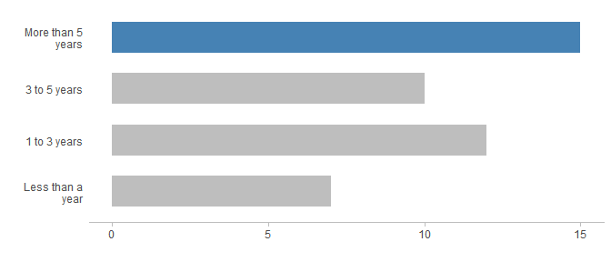

The group is relatively experienced using R – 57% of respondents have been using R for upwards of 3 years.

### Which R-related topics are you interested in hearing about?

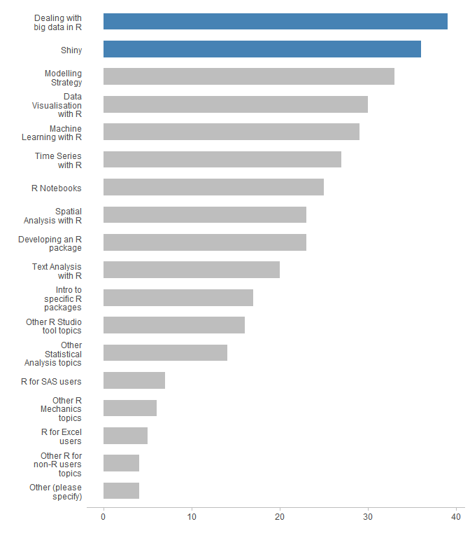

Dealing with big data in R is the most requested topic, followed closely by Shiny.

Suggetions from those that chose ‘other’:

- More on graphing/plotting in R/ggplot2 and how to make interactive plots with plotly
- What are the best places to learn R?
- What about non-R related data analysis work (i.e. topics with a statistical computing lens in general)?

### Are you interested in presenting at a WRUG meeting?

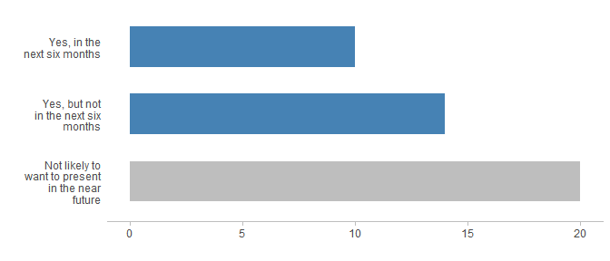

24 respondents are keen to present; 10 of these in the next six months.

### What is your preferred meeting time?

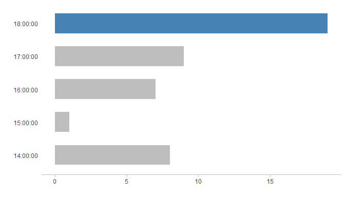

6pm is the most preferred meeting time.

### How often would you prefer this group to meet?

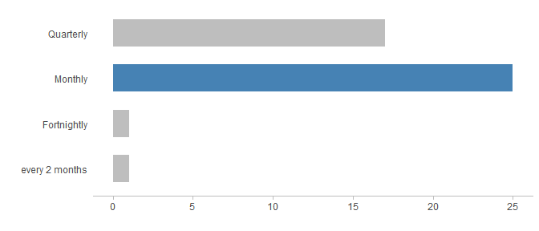

Most respondents would like meetings to be held monthly; followed closely by quarterly.

### How long would you prefer meetings to be?

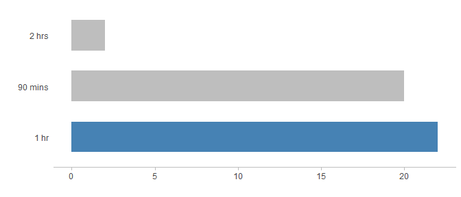

Respondents prefer meetings to be either 1hr or 90mins long.

### What kind of presentation structure do you prefer?

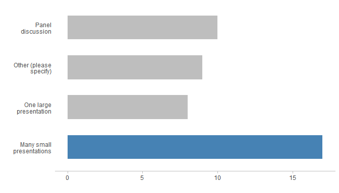

Respondents are interested in a variety of presentation structures.

Some suggestions from those that selected ‘other’:

- Large presentation + Panel discussion (without presentations).
- Mixture of all the above.
- Workshop-style presentation where attendees try things out on their own machines.
- Vary to fit topic. Also variation is good over time because different structures appeal to different users.

### Is there anything the organisers can do to encourage you to present?

Some suggestions:

- Identify interesting packages/techniques that need introduction.
- Suggest a topic related to genetics.
- Hold a beginner’s presentation night.
- Hold a ‘data blitz’ presentation night where each presenter gets < 10mins and then asks the audience for feedback.
- Give me sweets ;)
- Smaller groups.
- I don’t feel like I’m confident enough to present on R yet.

### Other comments or suggestions

- A talk on Microsoft Data Science Virtual Machine (DSVM)
- Using R integrated with other tools and databases
- Can the meeting be held somewhere close to the CBD?
- Could think about how to encourage informal, between meetings memebers. Perhaps mentoring/tutoring but without the structure. Coffee meetings?
- Perhaps there could be a subject stream in presentations about the practice of data analytics rather than the techniques
- Maybe we could mix up the presentation format, a couple of small vignette presentations and then one larger presentation?
- Sometimes these talks get boring, so we should keep the larger presentation for something really interesting/innovative.
- Maybe a small payment so that we get people that genuinely want to attend.
- Maybe an WRUG GitHub account can be made with the code put on there for those who couldnt make it.